# Fuel Management in Various Locations in California

Maia Pauley

10/21/2018

## Introduction

The recent increase in destructive wildfires in California has stirred up fearful questions about climate change, drought, and management practices. There are many conflicting theories about how to mitigate deadly wildfires, and this study planned to show whether or not prescribed burining and fuel management may be a piece of the puzzle. Early into this study, it became clear that the state of California prefers to allocate their resources to mitigate the effect of wildfires thruogh supression and containment rather than prevention techniques. For example, fire ecologist Dave Kinateder said, “Cal Fire spends the bulk of its resources battling fires rather than practicing preventative measures” (Cart, 2018).

The objective for this reaserch originally was to answer whether or not fire prevention methods such as prescribed burns or fuel management techniques are proven to decrease the frequency and intensity of wildfires in California. As I carried out the methods for this reaserch, my objective became slightly different. First, I randomly selected 7 counties in California with a random number generator and began reviewing their 2018 California Strategic Wildfire Plans. After looking for correlations between comprehensive fire plans (or lack thereof), and frequency and intensity of wildfires, I examined location difference to explain the variability of these results. Many scientists have proposed that fuel management practices should be location-specific and built off of extensive local research regarding vegetation makeup. For example, the California Chapparal Institute said, “Prescribed fires do have a place in mixed conifer forests, but NOT in chaparral and sage scrub plant communities” (Halsey, 2013).This study hopes to show that utilizing location-specific fuel management practices can help return an ecosystem to its natural fire regiments.

## Definitions

“Fuel” - Buildup of underbrush, that is highly flammable, and allows wildfires to spread and increase in intensity.

“Prescribed burns” - the controlled and monitored burning of certain areas to reduce fuel loads, and prevent susceptibility to larger wildfires. A tactic of fuel management.

## Do prescribed fire acres have an effect on the amount of acres burned from wildfires?

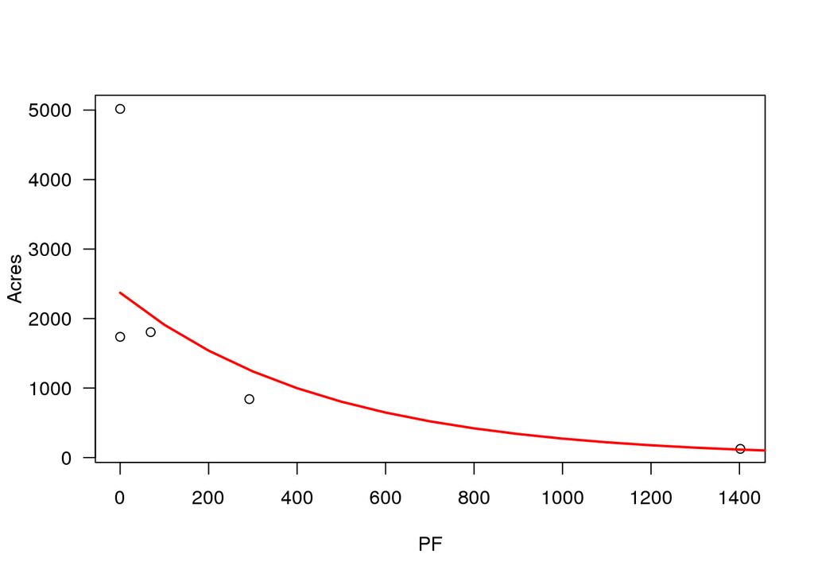

Statistical Results: The R-squared and adjusted R-squared value obtained from this regression is .8881 and .8508 respectively, showing that the data closely fit the exponential decay regression line. The standard error values for the Intercept and PF are .2843 and .0004 respectively, showing the precision of the regression line to the actual datapoints.

## Acres Burned as a function of Fuel Management Acres:

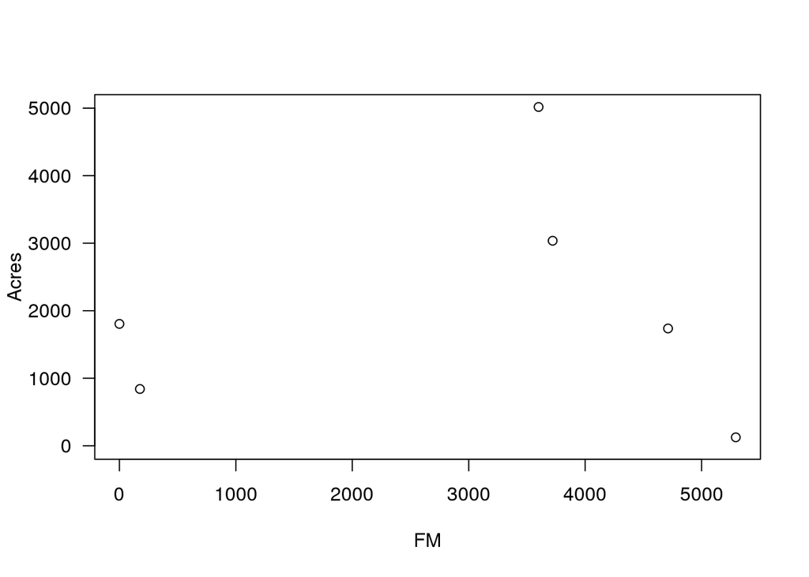

## Number of Wildfires as a function of Fuel Management Acres:

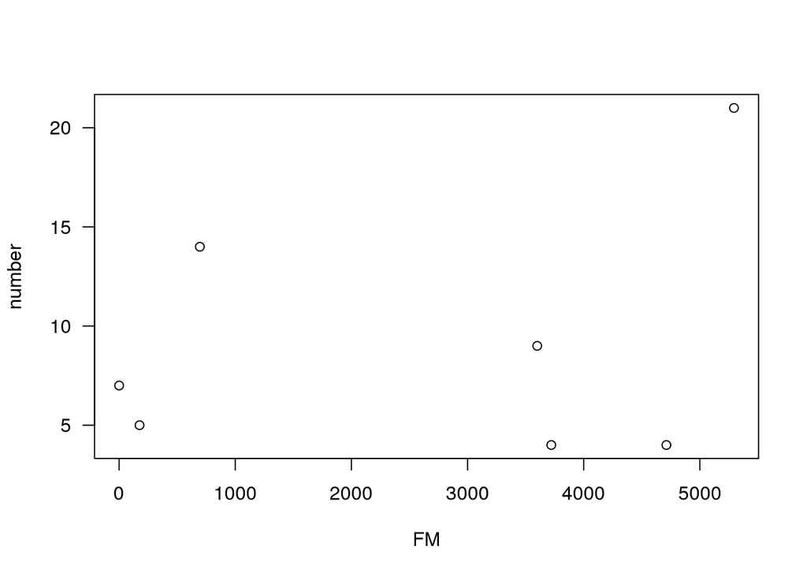

This figure compares how the acres of fuel management affects the number of fires burned from wildfires (instead of acres). There is no significant pattern between the acres of prescribed fires and number of fires across counties. This is likely due to several other factors and a lack of counties that we analyzed.

## Number of Fires as a function of Prescribed Fire Acres:

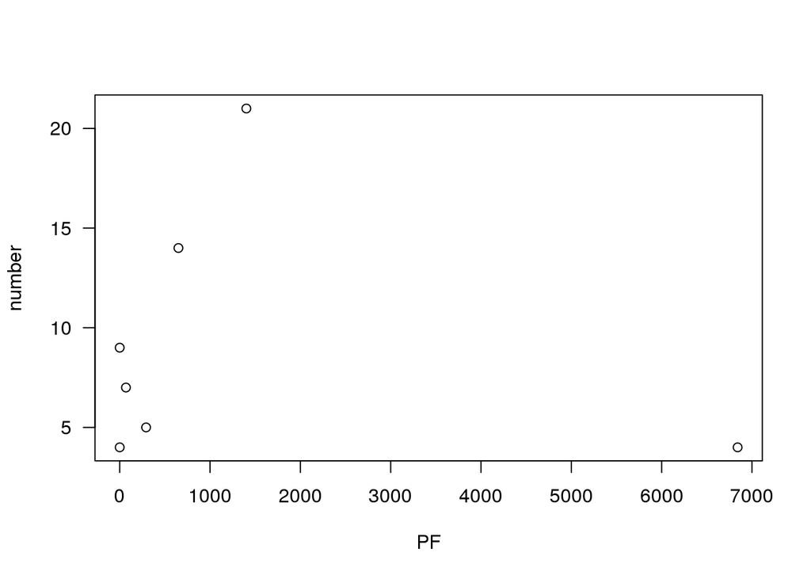

### Location Implications for Fuel Management

### Santa Barbara

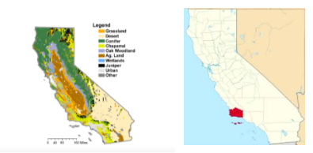

Chaparral

Santa Barbara lies in a chaparral biome–with flat plains, rocky hills, mountain slopes, and some grasslands. The fact that Santa Barbara had little information or data on fuel management and prescribed fires likely has to do with the fact that certain fuel management techniques such as fuel removal is much more difficult in a chaparral landscape. Because there are few trees, “removing the underbrush” does not seem practical because most vegetation in the area is underbrush. Some people argue that fuel reduction and prescribed fire should not be used in chaparral-covered hillsides in California in the same way that fuel reduction is used in forests. Riverside and Los Angeles

### Riverside and Los Angeles

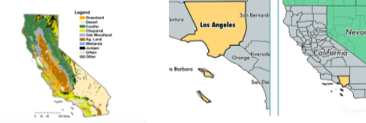

Chaparral Urban Area

### Kern

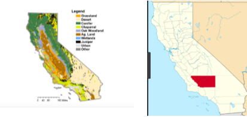

Desert, Chaparral and Conifer Forest

Kern County is further east than the two previous counties. Within Kern County, there is the Mojave Desert, chaparral, and some conifer forests. The desert biome is particularly prone to fires caused by lightning. Because there is little vegetation in the eastern half, it is reasonable that Kern County didn’t have any documented acres of prescribed fire.

### Nevada-Yuba

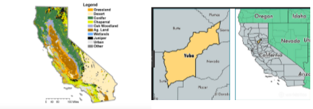

Grasslands, Oak Woodlands, and Conifer Forests

### Tulare

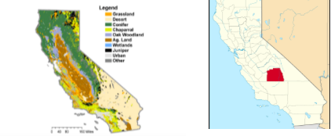

Desert, Chaparral, Conifer and Juniper Forests

Tulare County, located above Kern County, had a very small amount of prescribed fire acres and fuel management acres, at 292 and 176 respectively. Tulare has a very diverse vegetation with a small portion in the Mojave Desert, along with some chaparral, conifer and juniper forests. With the presence of juniper and chaparral, fuel management practices may be difficult due to the homogeneity in the height of the trees. People may be reluctant to invest resources into fuel management when prescribed burns or fuel removal might damage the natural ecosystem of the shorter shrubbery with little underbrush. Despite the lack of documented acreage of prescribed fire and fuel management, Tulare had the second smallest acreage of burns from wildfire.

### Shasta

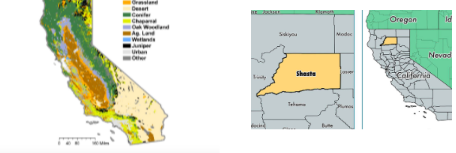

Conifer Forests

Shasta County, located in the uppermost section of California, is mainly dominated with Conifer forests. Shasta was the outlier in our data with a strikingly large amount of total acres burned by wildfire at 277,884 acres–over 55 times more acreage than the next highest at 5,017 in Kern County. This figure is from the massive Carr Fire that occurred in August, that spanned across both Shasta and Trinity Counties. Despite this being an anomaly in the data, Shasta County had less than 1,400 combined acres of prescribed fires and fuel management. Because this county is largely dominated with conifer forests, there is no reason why fuel management practices were sparse.

## Conclusion

Wildfires are bound to happen in California. My original belief, that Southern California has used excessive suppression techniques, has now shifted after looking at the data in terms of location. Our original thought was that fire suppression was disrupting natural fire regimes. And while this very well may be true, we must separate many more factors out of the equation to validate this conclusion. This may be true in northern counties with large portions of conifer forests, but southern counties are limited in their ability to practice fuel management because of their vegetation makeup. The data presented in the R analysis shows to be inconclusive, however some anomalies in these graphs seem to explain these anomalies.

In the future, if this test were to be redone, scientists should compare data in counties in close proximity. The inconsistency in the cdf Strategic Fire Plans throughout counties shows that that fuel management practices are locally specific. I do believe however comparing these data would be made much easier if each county was accountable for updating data on fuel management techniques. A centralized website to find these data is a good way for researchers to understand what techniques are working and which aren’t. A centralized website also ensures that researchers are not accidentally double counting fires because he or she needed to reference multiple.

California’s wildfire epidemic is highly involved with location based policies. Understanding how and why fuel management should be utilized will help California restore natural fire regimes as well as improve safety for California residents.

## References

References: “Biomes of California.” Home, civilizedape.weebly.com/biomes-of-california.html. California, State of. “California Statewide Maps.” CAL FIRE - Home, www.fire.ca.gov/current_incidents/?page=19. California, State of. “Fire Plans.” Fire Statistics, cdfdata.fire.ca.gov/fire_er/fpp_planning_plans. Cart, Julie. “California Fights Wildfires Aggressively-but Prevention Takes a Back Seat | CALmatters.” Google Search, Google, Mar. 2018, www.google.com/amp/s/calmatters.org/articles/california-fights-wildfires-aggressively-but-prevention-takes-a-back-seat/amp/. Halsey, Richard. Escaped Cal Fire Prescribed Burn San Felipe Valley Wildlife Area. 2013, Escaped Cal Fire Prescribed Burn San Felipe Valley Wildlife Area.